# BGE Skimming Analytics: Assembly Parameter Effects on Sequence Quality

BGE Project

2025-10-24

## Introduction

This analysis examines how assembly parameters affect sequence quality metrics in the BGE genome skimming project.

### Variables Under Investigation

**Independent Variables** (Assembly Parameters): - **r**: MGE (Mitochondrial Genome Extractor) parameter r value (float) - **s**: MGE parameter s value (integer) - **fcleaner**: Whether FASTA cleaner was applied (boolean) - **merge**: Whether data merging was applied (boolean)

**Dependent Variables** (Sequence Quality Metrics): - **nuc_full_basecount**: Total number of nucleotide bases in the full sequence - **ambig_full_basecount**: Total number of ambiguous bases in the full sequence - **stop_codons**: Number of stop codons detected

### Research Questions

1. How do different r and s parameter values affect sequence length and quality?
2. Does applying fcleaner or merge improve sequence quality (reduce ambiguous bases and stop codons)?
3. Are there interaction effects between parameters?
4. What parameter combinations produce the best results?

## Load Required Libraries

```r
library(readr)
library(dplyr)
library(ggplot2)
library(knitr)
library(tidyr)
```

## Read Data

```r
# Read the main analytics data
data <- read_tsv("../data/bge-skimming-analytics.tsv.gz")

cat("Dataset dimensions:", nrow(data), "rows,", ncol(data), "columns\n")
```

```
## Dataset dimensions: 330456 rows, 46 columns
```

## Data Preparation

```r
# Select relevant columns and remove rows with missing values in key variables
analysis_data <- data %>%
  select(group_id, sequence_id, r, s, fcleaner, merge,
         nuc_full_basecount, ambig_full_basecount, stop_codons,
         nuc_basecount, ambig_basecount) %>%
  filter(!is.na(r) & !is.na(s) & !is.na(fcleaner) & !is.na(merge) &
         !is.na(nuc_full_basecount) & !is.na(ambig_full_basecount) &
         !is.na(stop_codons))

cat("\nAnalysis dataset dimensions:", nrow(analysis_data), "rows\n")
```

```
##
## Analysis dataset dimensions: 330443 rows
```

```r
cat("Unique r values:", length(unique(analysis_data$r)), "\n")
```

```
## Unique r values: 3
```

```r
cat("Unique s values:", length(unique(analysis_data$s)), "\n")
```

```
## Unique s values: 2
```

```r
cat("fcleaner usage:", sprintf("%.1f%% True", 100 * mean(analysis_data$fcleaner)), "\n")
```

```
## fcleaner usage: 40.0% True
```

```r
cat("merge usage:", sprintf("%.1f%% True", 100 * mean(analysis_data$merge)), "\n")
```

```
## merge usage: 38.1% True
```

## Summary Statistics by Parameter

### Overall Summary

```r
# Summary statistics for dependent variables
summary_stats <- analysis_data %>%
  summarise(
    mean_nuc_full = mean(nuc_full_basecount, na.rm = TRUE),
    median_nuc_full = median(nuc_full_basecount, na.rm = TRUE),
    sd_nuc_full = sd(nuc_full_basecount, na.rm = TRUE),
    mean_ambig_full = mean(ambig_full_basecount, na.rm = TRUE),
    median_ambig_full = median(ambig_full_basecount, na.rm = TRUE),
    sd_ambig_full = sd(ambig_full_basecount, na.rm = TRUE),
    mean_stop_codons = mean(stop_codons, na.rm = TRUE),
    median_stop_codons = median(stop_codons, na.rm = TRUE),
    sd_stop_codons = sd(stop_codons, na.rm = TRUE)
  )

cat("\n=== Overall Summary Statistics ===\n\n")
```

```
##
## === Overall Summary Statistics ===
```

```r
cat("Full Sequence Nucleotide Base Count:\n")
```

```
## Full Sequence Nucleotide Base Count:
```

```r
cat("  Mean:", sprintf("%.1f", summary_stats$mean_nuc_full), "\n")
```

```
##   Mean: 1375.5
```

```r
cat("  Median:", summary_stats$median_nuc_full, "\n")
```

```
##   Median: 1530
```

```r
cat("  SD:", sprintf("%.1f", summary_stats$sd_nuc_full), "\n\n")
```

```
##   SD: 373.5
```

```r
cat("Full Sequence Ambiguous Base Count:\n")
```

```
## Full Sequence Ambiguous Base Count:
```

```r
cat("  Mean:", sprintf("%.2f", summary_stats$mean_ambig_full), "\n")
```

```
##   Mean: 5.51
```

```r
cat("  Median:", summary_stats$median_ambig_full, "\n")
```

```
##   Median: 0
```

```r
cat("  SD:", sprintf("%.2f", summary_stats$sd_ambig_full), "\n\n")
```

```
##   SD: 42.38
```

```r
cat("Stop Codons:\n")
```

```
## Stop Codons:
```

```r
cat("  Mean:", sprintf("%.2f", summary_stats$mean_stop_codons), "\n")
```

```
##   Mean: 0.02
```

```r
cat("  Median:", summary_stats$median_stop_codons, "\n")
```

```
##   Median: 0
```

```r
cat("  SD:", sprintf("%.2f", summary_stats$sd_stop_codons), "\n")
```

```
##   SD: 0.34
```

### Summary by r Parameter

```r
summary_by_r <- analysis_data %>%
  group_by(r) %>%
  summarise(
    n = n(),
    mean_nuc_full = mean(nuc_full_basecount),
    mean_ambig_full = mean(ambig_full_basecount),
    mean_stop_codons = mean(stop_codons),
    .groups = "drop"
  ) %>%
  arrange(r)

kable(summary_by_r,
      digits = 2,
      col.names = c("r", "N", "Mean Nuc Full", "Mean Ambig Full", "Mean Stop Codons"),
      caption = "Summary Statistics by r Parameter")
```

Summary Statistics by r Parameter

| r | N | Mean Nuc Full | Mean Ambig Full | Mean Stop Codons |
| --- | --- | --- | --- | --- |
| 1.0 | 110366 | 1426.82 | 7.46 | 0.01 |
| 1.3 | 110178 | 1380.65 | 4.26 | 0.01 |
| 1.5 | 109899 | 1318.73 | 4.79 | 0.02 |

### Summary by s Parameter

```r
summary_by_s <- analysis_data %>%
  group_by(s) %>%
  summarise(
    n = n(),
    mean_nuc_full = mean(nuc_full_basecount),
    mean_ambig_full = mean(ambig_full_basecount),
    mean_stop_codons = mean(stop_codons),
    .groups = "drop"
  ) %>%
  arrange(s)

kable(summary_by_s,
      digits = 2,
      col.names = c("s", "N", "Mean Nuc Full", "Mean Ambig Full", "Mean Stop Codons"),
      caption = "Summary Statistics by s Parameter")
```

Summary Statistics by s Parameter

| s | N | Mean Nuc Full | Mean Ambig Full | Mean Stop Codons |
| --- | --- | --- | --- | --- |
| 50 | 165567 | 1398.82 | 5.93 | 0.02 |
| 100 | 164876 | 1352.04 | 5.08 | 0.02 |

### Summary by fcleaner

```r
summary_by_fcleaner <- analysis_data %>%
  group_by(fcleaner) %>%
  summarise(
    n = n(),
    mean_nuc_full = mean(nuc_full_basecount),
    mean_ambig_full = mean(ambig_full_basecount),
    mean_stop_codons = mean(stop_codons),
    .groups = "drop"
  )

kable(summary_by_fcleaner,
      digits = 2,
      col.names = c("fcleaner", "N", "Mean Nuc Full", "Mean Ambig Full", "Mean Stop Codons"),
      caption = "Summary Statistics by fcleaner")
```

Summary Statistics by fcleaner

| fcleaner | N | Mean Nuc Full | Mean Ambig Full | Mean Stop Codons |
| --- | --- | --- | --- | --- |
| FALSE | 198229 | 1370.07 | 9.17 | 0.03 |
| TRUE | 132214 | 1383.58 | 0.01 | 0.00 |

### Summary by merge

```r
summary_by_merge <- analysis_data %>%
  group_by(merge) %>%
  summarise(
    n = n(),
    mean_nuc_full = mean(nuc_full_basecount),
    mean_ambig_full = mean(ambig_full_basecount),
    mean_stop_codons = mean(stop_codons),
    .groups = "drop"
  )

kable(summary_by_merge,
      digits = 2,
      col.names = c("merge", "N", "Mean Nuc Full", "Mean Ambig Full", "Mean Stop Codons"),
      caption = "Summary Statistics by merge")
```

Summary Statistics by merge

| merge | N | Mean Nuc Full | Mean Ambig Full | Mean Stop Codons |
| --- | --- | --- | --- | --- |
| FALSE | 204586 | 1384.03 | 6.30 | 0.02 |
| TRUE | 125857 | 1361.58 | 4.21 | 0.01 |

## Visualizations

### Effect of r Parameter

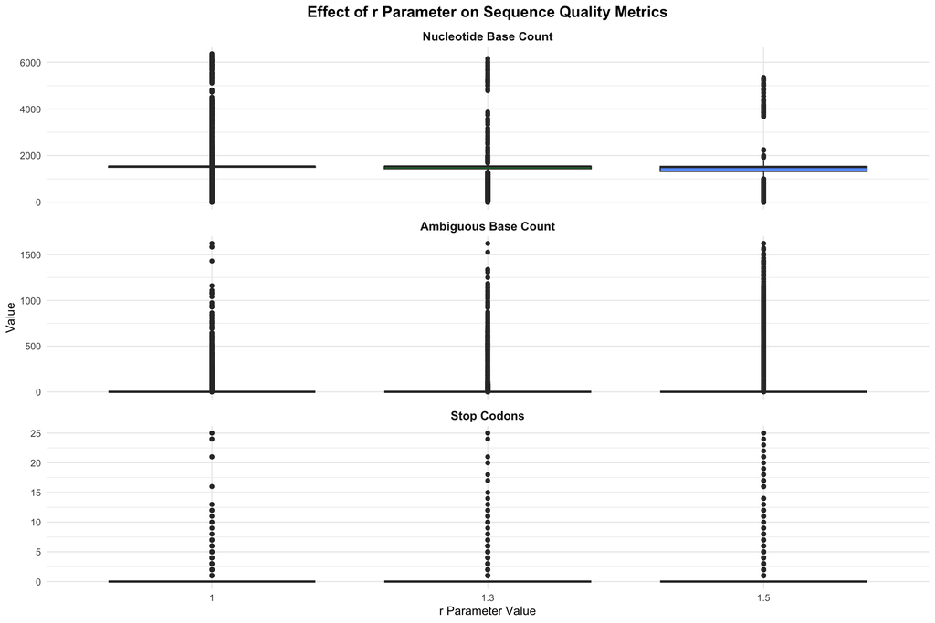

```r
# Create long format for plotting
plot_data_r <- analysis_data %>%
  select(r, nuc_full_basecount, ambig_full_basecount, stop_codons) %>%
  pivot_longer(cols = c(nuc_full_basecount, ambig_full_basecount, stop_codons),
               names_to = "metric",
               values_to = "value") %>%
  mutate(
    r = factor(r),
    metric = factor(metric,
                   levels = c("nuc_full_basecount", "ambig_full_basecount", "stop_codons"),
                   labels = c("Nucleotide Base Count", "Ambiguous Base Count", "Stop Codons"))
  )

ggplot(plot_data_r, aes(x = r, y = value, fill = r)) +
  geom_boxplot() +
  facet_wrap(~ metric, scales = "free_y", ncol = 1) +
  labs(
    title = "Effect of r Parameter on Sequence Quality Metrics",
    x = "r Parameter Value",
    y = "Value"
  ) +
  theme_minimal() +
  theme(
    plot.title = element_text(hjust = 0.5, size = 14, face = "bold"),
    legend.position = "none",
    strip.text = element_text(size = 11, face = "bold")
  )
```

### Effect of s Parameter

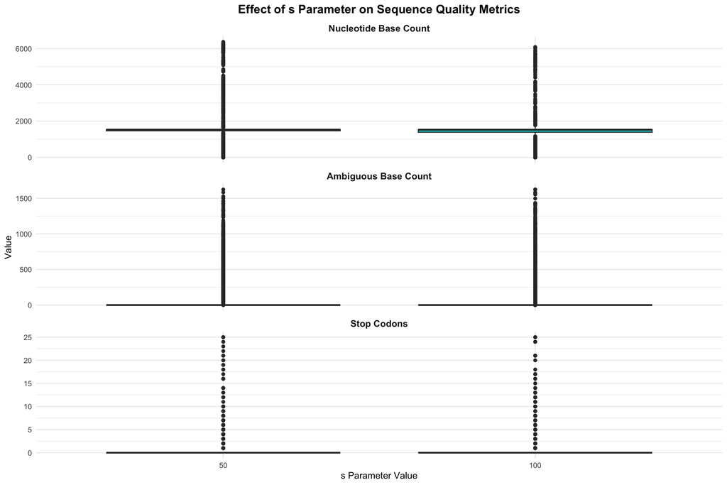

```r
# Create long format for plotting
plot_data_s <- analysis_data %>%
  select(s, nuc_full_basecount, ambig_full_basecount, stop_codons) %>%
  pivot_longer(cols = c(nuc_full_basecount, ambig_full_basecount, stop_codons),
               names_to = "metric",
               values_to = "value") %>%
  mutate(
    s = factor(s),
    metric = factor(metric,
                   levels = c("nuc_full_basecount", "ambig_full_basecount", "stop_codons"),
                   labels = c("Nucleotide Base Count", "Ambiguous Base Count", "Stop Codons"))
  )

ggplot(plot_data_s, aes(x = s, y = value, fill = s)) +
  geom_boxplot() +
  facet_wrap(~ metric, scales = "free_y", ncol = 1) +
  labs(
    title = "Effect of s Parameter on Sequence Quality Metrics",
    x = "s Parameter Value",
    y = "Value"
  ) +
  theme_minimal() +
  theme(
    plot.title = element_text(hjust = 0.5, size = 14, face = "bold"),
    legend.position = "none",
    strip.text = element_text(size = 11, face = "bold")
  )
```

### Effect of fcleaner

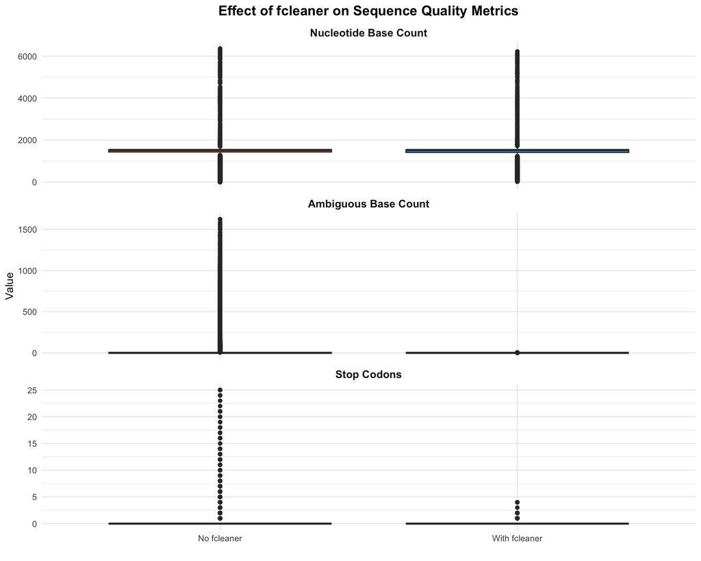

```r
plot_data_fcleaner <- analysis_data %>%
  select(fcleaner, nuc_full_basecount, ambig_full_basecount, stop_codons) %>%
  pivot_longer(cols = c(nuc_full_basecount, ambig_full_basecount, stop_codons),
               names_to = "metric",
               values_to = "value") %>%
  mutate(
    fcleaner = factor(fcleaner, levels = c(FALSE, TRUE), labels = c("No fcleaner", "With fcleaner")),
    metric = factor(metric,
                   levels = c("nuc_full_basecount", "ambig_full_basecount", "stop_codons"),
                   labels = c("Nucleotide Base Count", "Ambiguous Base Count", "Stop Codons"))
  )

ggplot(plot_data_fcleaner, aes(x = fcleaner, y = value, fill = fcleaner)) +
  geom_boxplot() +
  facet_wrap(~ metric, scales = "free_y", ncol = 1) +
  scale_fill_manual(values = c("No fcleaner" = "#e74c3c", "With fcleaner" = "#3498db")) +
  labs(
    title = "Effect of fcleaner on Sequence Quality Metrics",
    x = "",
    y = "Value"
  ) +
  theme_minimal() +
  theme(
    plot.title = element_text(hjust = 0.5, size = 14, face = "bold"),
    legend.position = "none",
    strip.text = element_text(size = 11, face = "bold")
  )
```

### Effect of merge

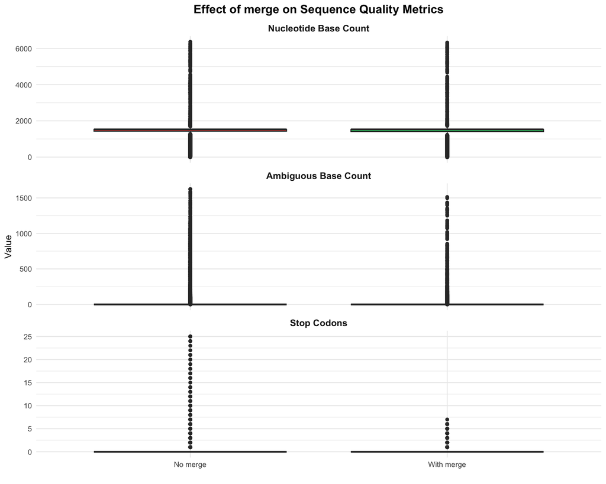

```r
plot_data_merge <- analysis_data %>%
  select(merge, nuc_full_basecount, ambig_full_basecount, stop_codons) %>%
  pivot_longer(cols = c(nuc_full_basecount, ambig_full_basecount, stop_codons),
               names_to = "metric",
               values_to = "value") %>%
  mutate(
    merge = factor(merge, levels = c(FALSE, TRUE), labels = c("No merge", "With merge")),
    metric = factor(metric,
                   levels = c("nuc_full_basecount", "ambig_full_basecount", "stop_codons"),
                   labels = c("Nucleotide Base Count", "Ambiguous Base Count", "Stop Codons"))
  )

ggplot(plot_data_merge, aes(x = merge, y = value, fill = merge)) +
  geom_boxplot() +
  facet_wrap(~ metric, scales = "free_y", ncol = 1) +
  scale_fill_manual(values = c("No merge" = "#e74c3c", "With merge" = "#2ecc71")) +
  labs(
    title = "Effect of merge on Sequence Quality Metrics",
    x = "",
    y = "Value"
  ) +
  theme_minimal() +
  theme(
    plot.title = element_text(hjust = 0.5, size = 14, face = "bold"),
    legend.position = "none",
    strip.text = element_text(size = 11, face = "bold")
  )
```

## Interaction Effects

### r × s Interaction

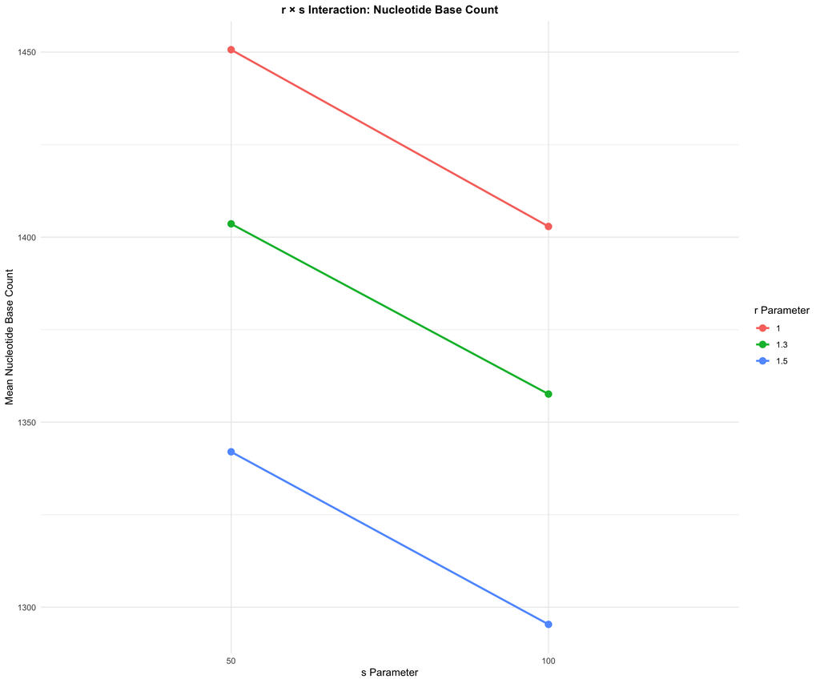

```r
# Create interaction data
interaction_rs <- analysis_data %>%
  group_by(r, s) %>%
  summarise(
    mean_nuc_full = mean(nuc_full_basecount),
    mean_ambig_full = mean(ambig_full_basecount),
    mean_stop_codons = mean(stop_codons),
    n = n(),
    .groups = "drop"
  )

# Plot interaction for nuc_full_basecount
p1 <- ggplot(interaction_rs, aes(x = factor(s), y = mean_nuc_full, color = factor(r), group = r)) +
  geom_line(size = 1) +
  geom_point(size = 3) +
  labs(
    title = "r × s Interaction: Nucleotide Base Count",
    x = "s Parameter",
    y = "Mean Nucleotide Base Count",
    color = "r Parameter"
  ) +
  theme_minimal() +
  theme(plot.title = element_text(hjust = 0.5, size = 12, face = "bold"))

# Plot interaction for ambig_full_basecount
p2 <- ggplot(interaction_rs, aes(x = factor(s), y = mean_ambig_full, color = factor(r), group = r)) +
  geom_line(size = 1) +
  geom_point(size = 3) +
  labs(
    title = "r × s Interaction: Ambiguous Base Count",
    x = "s Parameter",
    y = "Mean Ambiguous Base Count",
    color = "r Parameter"
  ) +
  theme_minimal() +
  theme(plot.title = element_text(hjust = 0.5, size = 12, face = "bold"))

# Plot interaction for stop_codons
p3 <- ggplot(interaction_rs, aes(x = factor(s), y = mean_stop_codons, color = factor(r), group = r)) +
  geom_line(size = 1) +
  geom_point(size = 3) +
  labs(
    title = "r × s Interaction: Stop Codons",
    x = "s Parameter",
    y = "Mean Stop Codons",
    color = "r Parameter"
  ) +
  theme_minimal() +
  theme(plot.title = element_text(hjust = 0.5, size = 12, face = "bold"))

# Display plots
p1
```

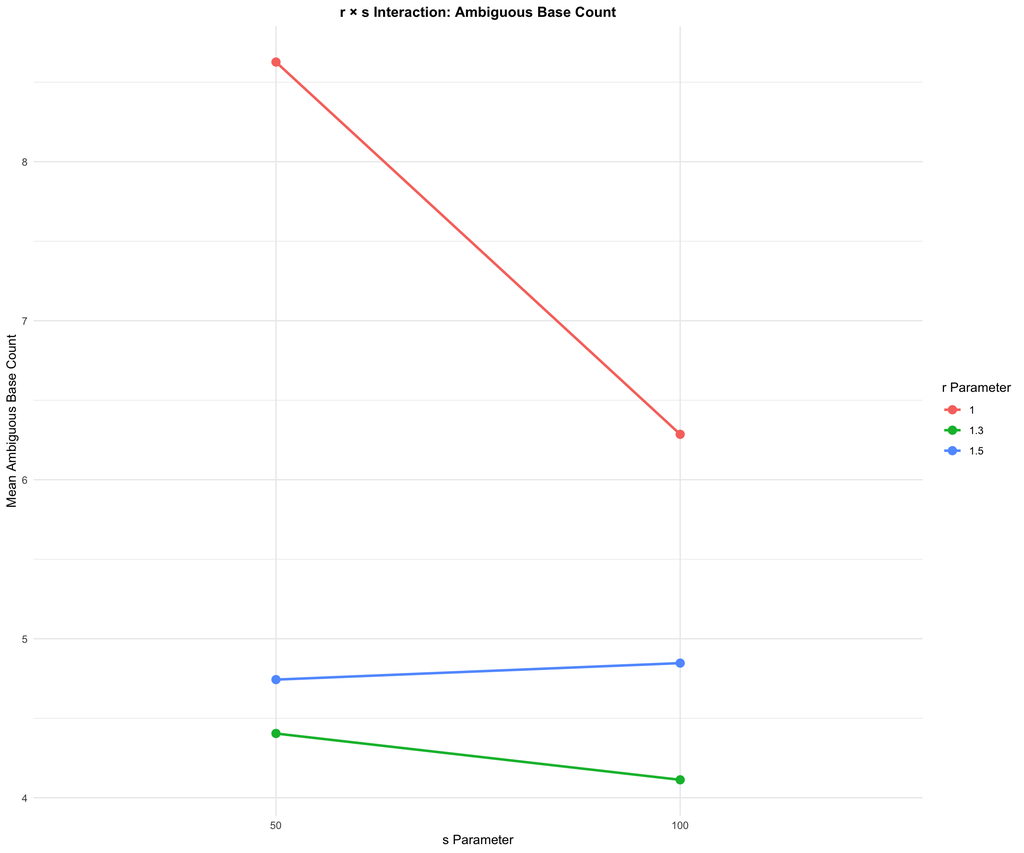

```r
p2
```

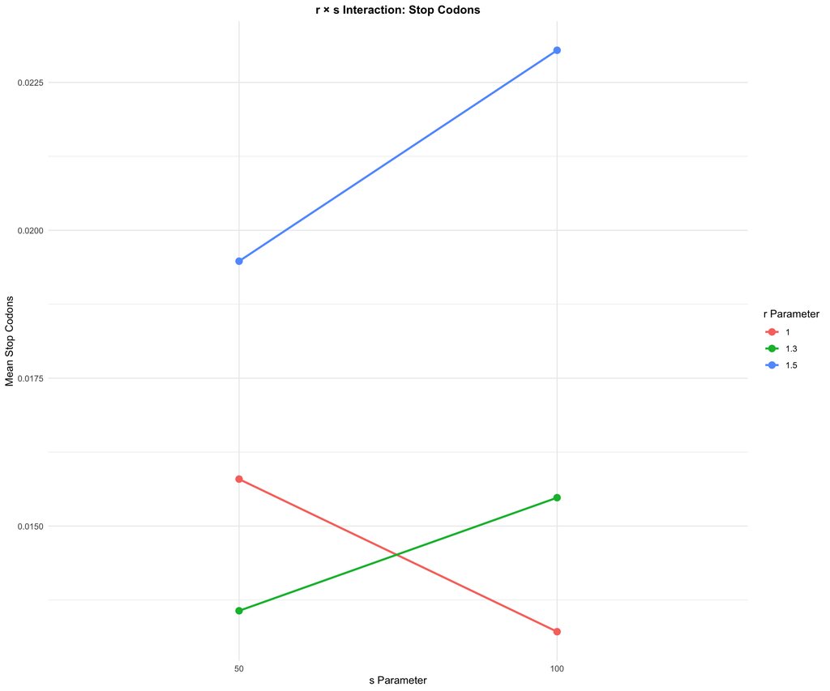

```r
p3
```

### fcleaner × merge Interaction

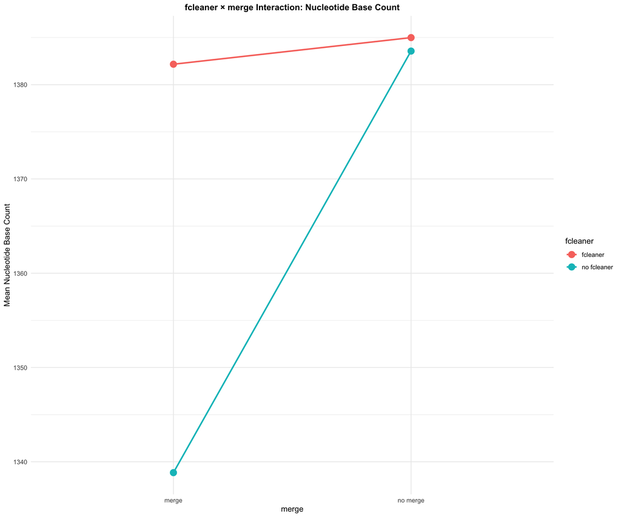

```r
# Create interaction data
interaction_fm <- analysis_data %>%
  group_by(fcleaner, merge) %>%
  summarise(
    mean_nuc_full = mean(nuc_full_basecount),
    mean_ambig_full = mean(ambig_full_basecount),
    mean_stop_codons = mean(stop_codons),
    n = n(),
    .groups = "drop"
  ) %>%
  mutate(
    fcleaner_label = ifelse(fcleaner, "fcleaner", "no fcleaner"),
    merge_label = ifelse(merge, "merge", "no merge")
  )

# Plot interaction for nuc_full_basecount
p1 <- ggplot(interaction_fm, aes(x = merge_label, y = mean_nuc_full, color = fcleaner_label, group = fcleaner_label)) +
  geom_line(size = 1) +
  geom_point(size = 4) +
  labs(
    title = "fcleaner × merge Interaction: Nucleotide Base Count",
    x = "merge",
    y = "Mean Nucleotide Base Count",
    color = "fcleaner"
  ) +
  theme_minimal() +
  theme(plot.title = element_text(hjust = 0.5, size = 12, face = "bold"))

# Plot interaction for ambig_full_basecount
p2 <- ggplot(interaction_fm, aes(x = merge_label, y = mean_ambig_full, color = fcleaner_label, group = fcleaner_label)) +
  geom_line(size = 1) +
  geom_point(size = 4) +
  labs(
    title = "fcleaner × merge Interaction: Ambiguous Base Count",
    x = "merge",
    y = "Mean Ambiguous Base Count",
    color = "fcleaner"
  ) +
  theme_minimal() +
  theme(plot.title = element_text(hjust = 0.5, size = 12, face = "bold"))

# Plot interaction for stop_codons
p3 <- ggplot(interaction_fm, aes(x = merge_label, y = mean_stop_codons, color = fcleaner_label, group = fcleaner_label)) +
  geom_line(size = 1) +
  geom_point(size = 4) +
  labs(
    title = "fcleaner × merge Interaction: Stop Codons",
    x = "merge",
    y = "Mean Stop Codons",
    color = "fcleaner"
  ) +
  theme_minimal() +
  theme(plot.title = element_text(hjust = 0.5, size = 12, face = "bold"))

# Display plots
p1
```

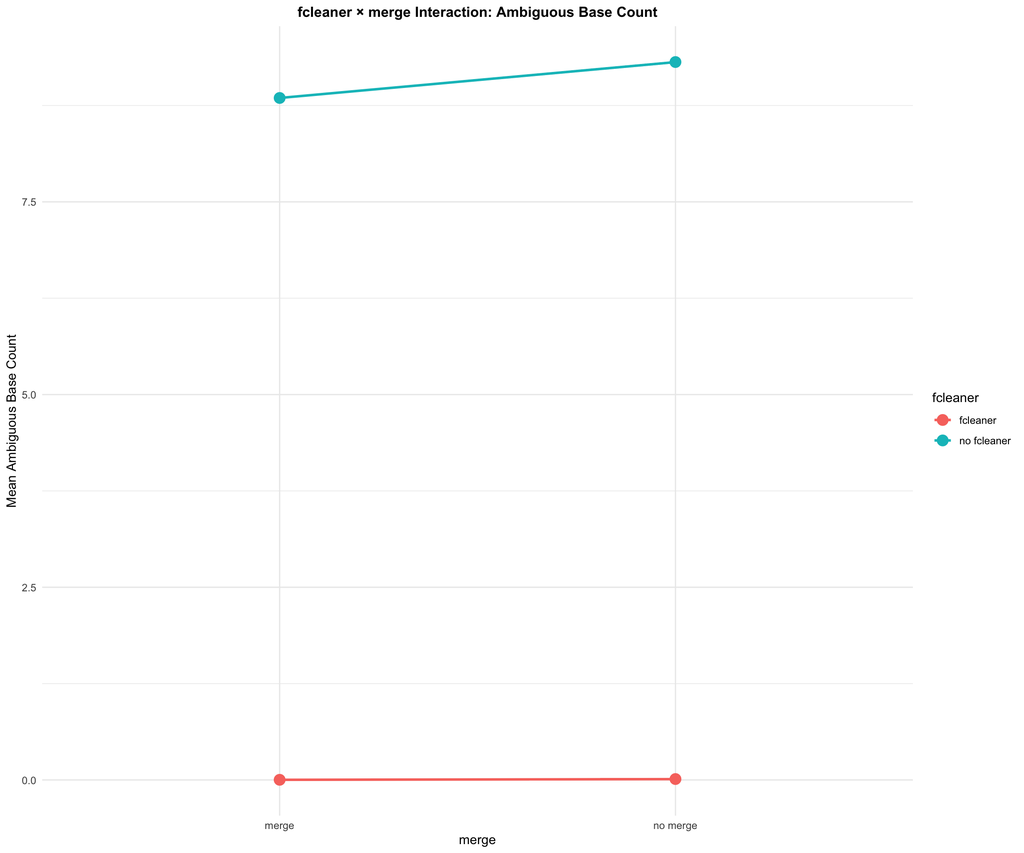

```r
p2
```

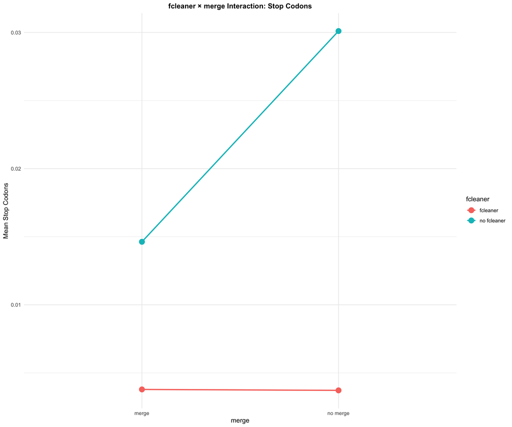

```r
p3
```

## Statistical Tests

### ANOVA for r Parameter

```r
cat("\n=== ANOVA: Effect of r Parameter ===\n\n")
```

```
##
## === ANOVA: Effect of r Parameter ===
```

```r
# Convert r to factor for ANOVA
analysis_data$r_factor <- factor(analysis_data$r)

# ANOVA for nuc_full_basecount
anova_r_nuc <- aov(nuc_full_basecount ~ r_factor, data = analysis_data)
cat("Nucleotide Base Count:\n")
```

```
## Nucleotide Base Count:
```

```r
print(summary(anova_r_nuc))
```

```
##                 Df    Sum Sq   Mean Sq F value Pr(>F)
## r_factor         2 6.477e+08 323836929    2354 <2e-16 ***
## Residuals   330440 4.546e+10    137560
## ---
## Signif. codes:  0 '***' 0.001 '**' 0.01 '*' 0.05 '.' 0.1 ' ' 1
```

```r
# ANOVA for ambig_full_basecount
anova_r_ambig <- aov(ambig_full_basecount ~ r_factor, data = analysis_data)
cat("\nAmbiguous Base Count:\n")
```

```
##
## Ambiguous Base Count:
```

```r
print(summary(anova_r_ambig))
```

```
##                 Df    Sum Sq Mean Sq F value Pr(>F)
## r_factor         2    647539  323769   180.5 <2e-16 ***
## Residuals   330440 592872185    1794
## ---
## Signif. codes:  0 '***' 0.001 '**' 0.01 '*' 0.05 '.' 0.1 ' ' 1
```

```r
# ANOVA for stop_codons
anova_r_stop <- aov(stop_codons ~ r_factor, data = analysis_data)
cat("\nStop Codons:\n")
```

```
##
## Stop Codons:
```

```r
print(summary(anova_r_stop))
```

```
##                 Df Sum Sq Mean Sq F value  Pr(>F)
## r_factor         2      3  1.6669   14.57 4.7e-07 ***
## Residuals   330440  37799  0.1144
## ---
## Signif. codes:  0 '***' 0.001 '**' 0.01 '*' 0.05 '.' 0.1 ' ' 1
```

### ANOVA for s Parameter

```r
cat("\n=== ANOVA: Effect of s Parameter ===\n\n")
```

```
##
## === ANOVA: Effect of s Parameter ===
```

```r
# Convert s to factor for ANOVA
analysis_data$s_factor <- factor(analysis_data$s)

# ANOVA for nuc_full_basecount
anova_s_nuc <- aov(nuc_full_basecount ~ s_factor, data = analysis_data)
cat("Nucleotide Base Count:\n")
```

```
## Nucleotide Base Count:
```

```r
print(summary(anova_s_nuc))
```

```
##                 Df    Sum Sq   Mean Sq F value Pr(>F)
## s_factor         1 1.808e+08 180756341    1301 <2e-16 ***
## Residuals   330441 4.592e+10    138973
## ---
## Signif. codes:  0 '***' 0.001 '**' 0.01 '*' 0.05 '.' 0.1 ' ' 1
```

```r
# ANOVA for ambig_full_basecount
anova_s_ambig <- aov(ambig_full_basecount ~ s_factor, data = analysis_data)
cat("\nAmbiguous Base Count:\n")
```

```
##
## Ambiguous Base Count:
```

```r
print(summary(anova_s_ambig))
```

```
##                 Df    Sum Sq Mean Sq F value   Pr(>F)
## s_factor         1     58821   58821   32.75 1.05e-08 ***
## Residuals   330441 593460903    1796
## ---
## Signif. codes:  0 '***' 0.001 '**' 0.01 '*' 0.05 '.' 0.1 ' ' 1
```

```r
# ANOVA for stop_codons
anova_s_stop <- aov(stop_codons ~ s_factor, data = analysis_data)
cat("\nStop Codons:\n")
```

```
##
## Stop Codons:
```

```r
print(summary(anova_s_stop))
```

```
##                 Df Sum Sq Mean Sq F value Pr(>F)
## s_factor         1      0  0.0761   0.665  0.415
## Residuals   330441  37802  0.1144
```

### T-tests for fcleaner

```r
cat("\n=== T-tests: Effect of fcleaner ===\n\n")
```

```
##
## === T-tests: Effect of fcleaner ===
```

```r
# T-test for nuc_full_basecount
ttest_fcleaner_nuc <- t.test(nuc_full_basecount ~ fcleaner, data = analysis_data)
cat("Nucleotide Base Count:\n")
```

```
## Nucleotide Base Count:
```

```r
print(ttest_fcleaner_nuc)
```

```
##
##  Welch Two Sample t-test
##
## data:  nuc_full_basecount by fcleaner
## t = -10.462, df = 306992, p-value < 2.2e-16
## alternative hypothesis: true difference in means between group FALSE and group TRUE is not equal to 0
## 95 percent confidence interval:
##  -16.04779 -10.98347
## sample estimates:
## mean in group FALSE  mean in group TRUE
##            1370.068            1383.584
```

```r
# T-test for ambig_full_basecount
ttest_fcleaner_ambig <- t.test(ambig_full_basecount ~ fcleaner, data = analysis_data)
cat("\nAmbiguous Base Count:\n")
```

```
##
## Ambiguous Base Count:
```

```r
print(ttest_fcleaner_ambig)
```

```
##
##  Welch Two Sample t-test
##
## data:  ambig_full_basecount by fcleaner
## t = 75.003, df = 198230, p-value < 2.2e-16
## alternative hypothesis: true difference in means between group FALSE and group TRUE is not equal to 0
## 95 percent confidence interval:
##  8.926511 9.405561
## sample estimates:
## mean in group FALSE  mean in group TRUE
##         9.173168406         0.007132376
```

```r
# T-test for stop_codons
ttest_fcleaner_stop <- t.test(stop_codons ~ fcleaner, data = analysis_data)
cat("\nStop Codons:\n")
```

```
##
## Stop Codons:
```

```r
print(ttest_fcleaner_stop)
```

```
##
##  Welch Two Sample t-test
##
## data:  stop_codons by fcleaner
## t = 21.88, df = 213650, p-value < 2.2e-16
## alternative hypothesis: true difference in means between group FALSE and group TRUE is not equal to 0
## 95 percent confidence interval:
##  0.01973671 0.02362067
## sample estimates:
## mean in group FALSE  mean in group TRUE
##         0.025430184         0.003751494
```

### T-tests for merge

```r
cat("\n=== T-tests: Effect of merge ===\n\n")
```

```
##
## === T-tests: Effect of merge ===
```

```r
# T-test for nuc_full_basecount
ttest_merge_nuc <- t.test(nuc_full_basecount ~ merge, data = analysis_data)
cat("Nucleotide Base Count:\n")
```

```
## Nucleotide Base Count:
```

```r
print(ttest_merge_nuc)
```

```
##
##  Welch Two Sample t-test
##
## data:  nuc_full_basecount by merge
## t = 16.37, df = 245088, p-value < 2.2e-16
## alternative hypothesis: true difference in means between group FALSE and group TRUE is not equal to 0
## 95 percent confidence interval:
##  19.76290 25.13881
## sample estimates:
## mean in group FALSE  mean in group TRUE
##            1384.027            1361.576
```

```r
# T-test for ambig_full_basecount
ttest_merge_ambig <- t.test(ambig_full_basecount ~ merge, data = analysis_data)
cat("\nAmbiguous Base Count:\n")
```

```
##
## Ambiguous Base Count:
```

```r
print(ttest_merge_ambig)
```

```
##
##  Welch Two Sample t-test
##
## data:  ambig_full_basecount by merge
## t = 14.601, df = 310315, p-value < 2.2e-16
## alternative hypothesis: true difference in means between group FALSE and group TRUE is not equal to 0
## 95 percent confidence interval:
##  1.816331 2.379591
## sample estimates:
## mean in group FALSE  mean in group TRUE
##            6.304791            4.206830
```

```r
# T-test for stop_codons
ttest_merge_stop <- t.test(stop_codons ~ merge, data = analysis_data)
cat("\nStop Codons:\n")
```

```
##
## Stop Codons:
```

```r
print(ttest_merge_stop)
```

```
##
##  Welch Two Sample t-test
##
## data:  stop_codons by merge
## t = 12.462, df = 287776, p-value < 2.2e-16
## alternative hypothesis: true difference in means between group FALSE and group TRUE is not equal to 0
## 95 percent confidence interval:
##  0.01064093 0.01461265
## sample estimates:
## mean in group FALSE  mean in group TRUE
##         0.021565503         0.008938716
```

## Parameter Combination Analysis

### Best Parameter Combinations

```r
# Find best parameter combinations for each metric
best_combos <- analysis_data %>%
  group_by(r, s, fcleaner, merge) %>%
  summarise(
    n = n(),
    mean_nuc_full = mean(nuc_full_basecount),
    mean_ambig_full = mean(ambig_full_basecount),
    mean_stop_codons = mean(stop_codons),
    .groups = "drop"
  ) %>%
  filter(n >= 10)  # Only consider combinations with at least 10 observations

cat("\n=== Top 10 Parameter Combinations by Nucleotide Base Count ===\n")
```

```
##
## === Top 10 Parameter Combinations by Nucleotide Base Count ===
```

```r
best_combos %>%
  arrange(desc(mean_nuc_full)) %>%
  head(10) %>%
  kable(digits = 2)
```

| r | s | fcleaner | merge | n | mean_nuc_full | mean_ambig_full | mean_stop_codons |
| --- | --- | --- | --- | --- | --- | --- | --- |
| 1.0 | 50 | FALSE | FALSE | 23068 | 1460.96 | 14.72 | 0.02 |
| 1.0 | 50 | TRUE | FALSE | 11125 | 1457.12 | 0.01 | 0.01 |
| 1.0 | 50 | TRUE | TRUE | 11110 | 1448.99 | 0.00 | 0.01 |
| 1.0 | 50 | FALSE | TRUE | 9971 | 1421.52 | 13.74 | 0.02 |
| 1.0 | 100 | FALSE | FALSE | 23067 | 1416.98 | 11.28 | 0.02 |
| 1.3 | 50 | FALSE | FALSE | 23069 | 1412.51 | 7.57 | 0.02 |
| 1.3 | 50 | TRUE | FALSE | 11092 | 1410.73 | 0.01 | 0.00 |
| 1.0 | 100 | TRUE | FALSE | 11041 | 1408.46 | 0.01 | 0.00 |
| 1.3 | 50 | TRUE | TRUE | 11072 | 1407.08 | 0.00 | 0.00 |
| 1.0 | 100 | TRUE | TRUE | 11013 | 1402.11 | 0.00 | 0.00 |

```r
cat("\n=== Top 10 Parameter Combinations by Lowest Ambiguous Bases ===\n")
```

```
##
## === Top 10 Parameter Combinations by Lowest Ambiguous Bases ===
```

```r
best_combos %>%
  arrange(mean_ambig_full) %>%
  head(10) %>%
  kable(digits = 2)
```

| r | s | fcleaner | merge | n | mean_nuc_full | mean_ambig_full | mean_stop_codons |
| --- | --- | --- | --- | --- | --- | --- | --- |
| 1.3 | 50 | TRUE | TRUE | 11072 | 1407.08 | 0.00 | 0.00 |
| 1.5 | 50 | TRUE | TRUE | 11014 | 1350.30 | 0.00 | 0.00 |
| 1.3 | 100 | TRUE | TRUE | 10956 | 1367.91 | 0.00 | 0.00 |
| 1.5 | 100 | TRUE | TRUE | 10867 | 1314.95 | 0.00 | 0.00 |
| 1.0 | 50 | TRUE | TRUE | 11110 | 1448.99 | 0.00 | 0.01 |
| 1.0 | 100 | TRUE | TRUE | 11013 | 1402.11 | 0.00 | 0.00 |
| 1.5 | 50 | TRUE | FALSE | 11038 | 1350.44 | 0.01 | 0.00 |
| 1.5 | 100 | TRUE | FALSE | 10906 | 1311.94 | 0.01 | 0.00 |
| 1.3 | 50 | TRUE | FALSE | 11092 | 1410.73 | 0.01 | 0.00 |
| 1.0 | 50 | TRUE | FALSE | 11125 | 1457.12 | 0.01 | 0.01 |

```r
cat("\n=== Top 10 Parameter Combinations by Lowest Stop Codons ===\n")
```

```
##
## === Top 10 Parameter Combinations by Lowest Stop Codons ===
```

```r
best_combos %>%
  arrange(mean_stop_codons) %>%
  head(10) %>%
  kable(digits = 2)
```

| r | s | fcleaner | merge | n | mean_nuc_full | mean_ambig_full | mean_stop_codons |
| --- | --- | --- | --- | --- | --- | --- | --- |
| 1.5 | 100 | TRUE | FALSE | 10906 | 1311.94 | 0.01 | 0 |
| 1.5 | 100 | TRUE | TRUE | 10867 | 1314.95 | 0.00 | 0 |
| 1.5 | 50 | TRUE | TRUE | 11014 | 1350.30 | 0.00 | 0 |
| 1.3 | 100 | TRUE | TRUE | 10956 | 1367.91 | 0.00 | 0 |
| 1.3 | 100 | TRUE | FALSE | 10980 | 1369.62 | 0.01 | 0 |
| 1.3 | 50 | TRUE | FALSE | 11092 | 1410.73 | 0.01 | 0 |
| 1.5 | 50 | TRUE | FALSE | 11038 | 1350.44 | 0.01 | 0 |
| 1.3 | 50 | TRUE | TRUE | 11072 | 1407.08 | 0.00 | 0 |
| 1.0 | 100 | TRUE | FALSE | 11041 | 1408.46 | 0.01 | 0 |
| 1.0 | 100 | TRUE | TRUE | 11013 | 1402.11 | 0.00 | 0 |